# P1-Statistical Learning

## IV) Clustering

Be careful: here we use same data set as in factor analysis and we scale it.

1. Do we have good data to do a clustering?

First we need to check if our data is susceptible to do a cluster analysis. To do so, we compute a distance matrix. Then, we plot it using fviz_dist function with the euclidean method which is the most common. However, since we have more than a thousand observations we decided to only plot only 150 to be able to interpret the distance matrix graph.

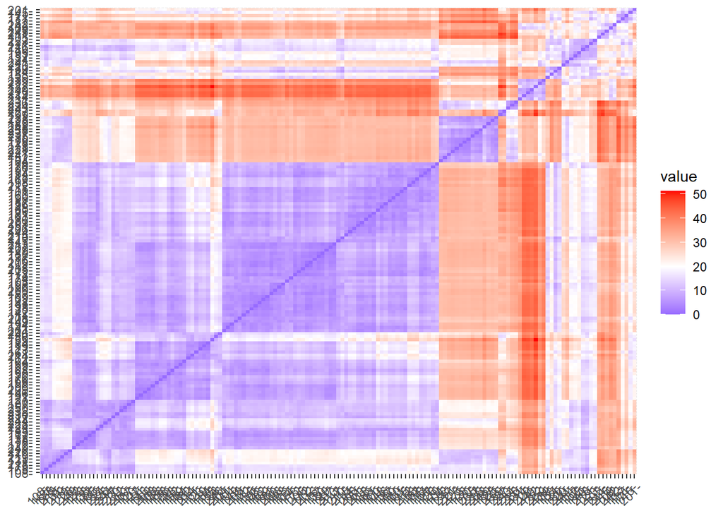

```r
library(tidyverse)
library(GGally) # ggplot2-based visualization of correlations
library(factoextra) # ggplot2-based visualization of pca
library(cluster)
library(mclust)
library(tidyr)

X = scale(data)
m.distance <- get_dist(data[100:250,], method = "euclidean") #we also can use: "maximum", "manhattan", "canberra", "binary", "minkowski", "pearson", "spearman" or "kendall"
fviz_dist(m.distance, gradient = list(low = "blue", mid = "white", high = "red"))
```

2. Estimation of the optimal number of clusters

We plot screeplots using different methods to compute the optimal number which is the one that has the biggest change in the slope of the curve

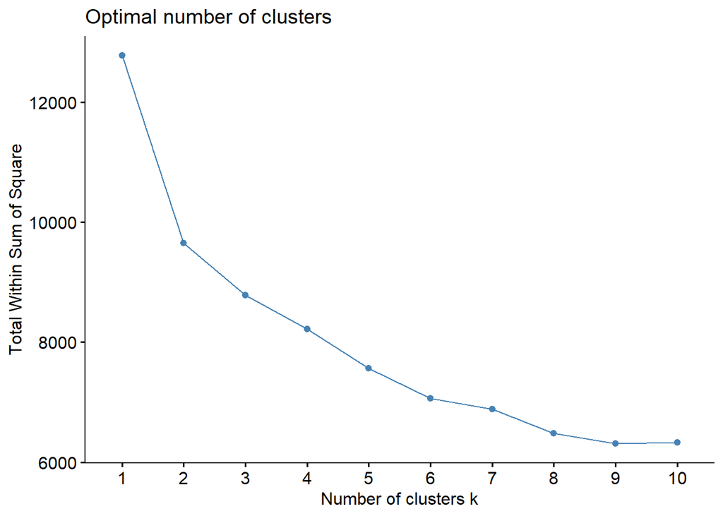

```r
fviz_nbclust(X, kmeans, method = 'wss')
```

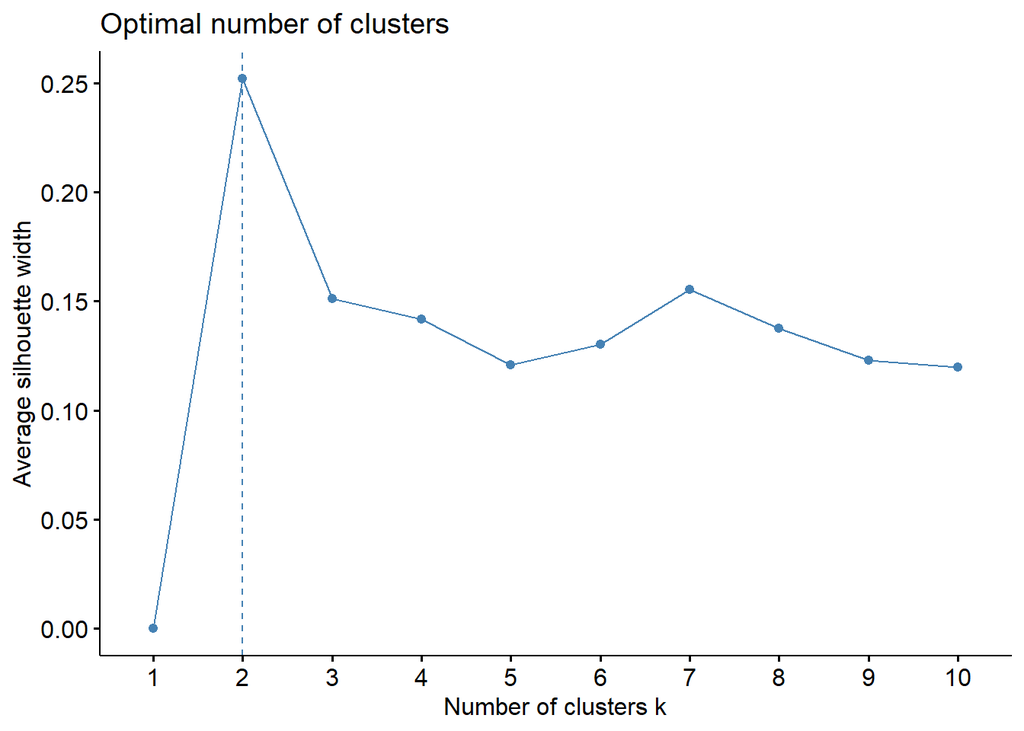

```r
fviz_nbclust(X, kmeans, method = 'silhouette')
```

```r
#fviz_nbclust(X, kmeans, method = 'gap_stat', k.max = 20)
```

2 is the optimal based on our results using different methods. It is this number since it is the point with the highest change in the slope. 6 appeared with bootstrap method (you can run it deleting #) but we think this is too much for only 10 variables.

Now we take 2 centers and the observations as a function of its center

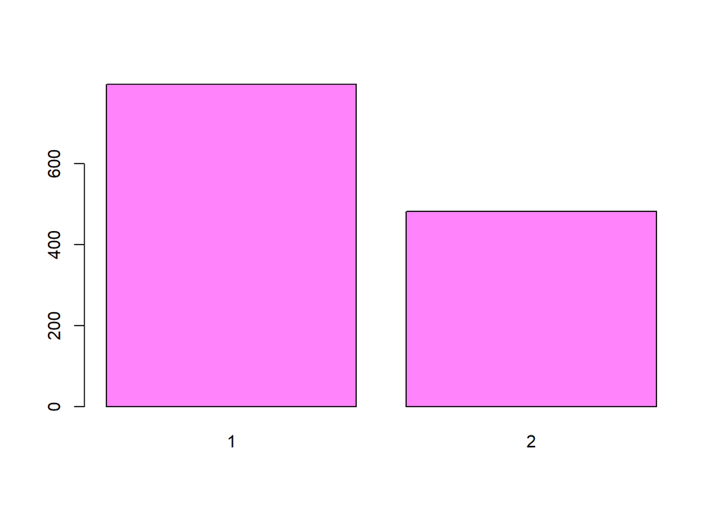

```r
fit = kmeans(X, centers=2, nstart=100)

groups = fit$cluster
barplot(table(groups), col="#FF83FA")
```

```r
centers=fit$centers
centers
```

```
##   Diabetes_012        BMI    GenHlth   MentHlth   PhysHlth        Age
## 1   -0.4288298 -0.2086191 -0.5490057 -0.3098797 -0.5183347 -0.1403706
## 2    0.7081920  0.3445245  0.9066567  0.5117516  0.8560050  0.2318153
##    Education     Income  Badthings Goodthings
## 1  0.2411041  0.4224403 -0.4887790  0.2991692
## 2 -0.3981720 -0.6976400  0.8071952 -0.4940636
```

We plot the centers in cluster 1 and 2. The purple bars represent the center of a group, whereas the orange points are the center of all the observations:

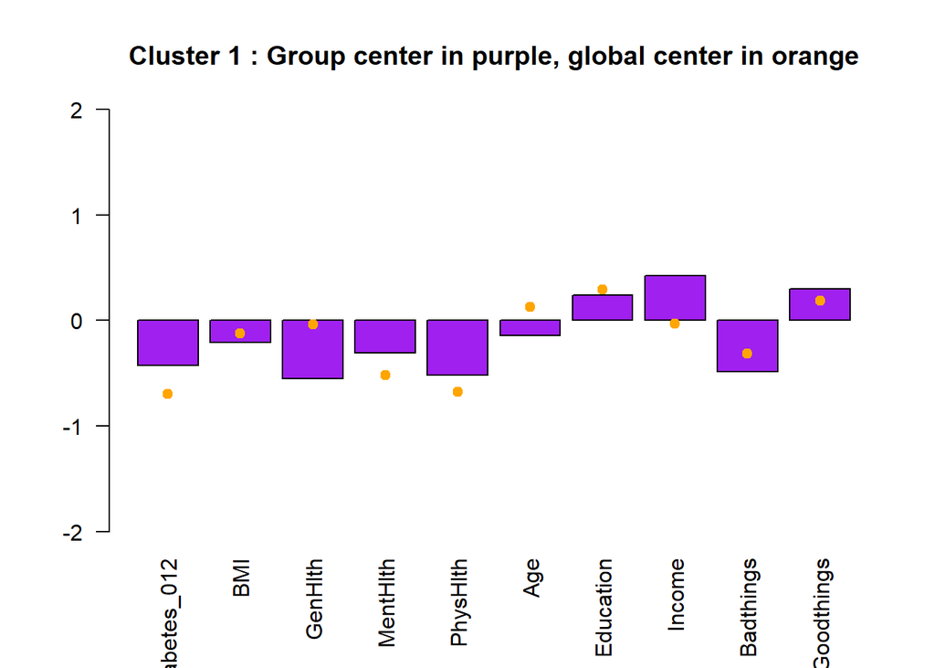

```r
#cluster 1
i=1
bar1=barplot(centers[i,], las=2, col="purple", ylim=c(-2,2), main=paste("Cluster", i,": Group center in purple, global center in orange"))
points(bar1,y=apply(X, 2, quantile, 0.50),col="orange",pch=19)
```

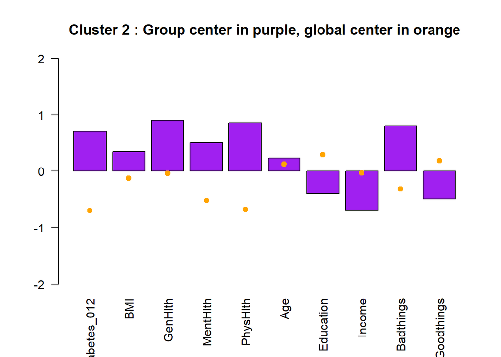

```r
#cluster 2
i=2
bar2=barplot(centers[i,], las=2, col="purple", ylim=c(-2,2), main=paste("Cluster", i,": Group center in purple, global center in orange"))
points(bar2,y=apply(X, 2, quantile, 0.50),col="orange",pch=19)
```

3. The Silhouette plot

The silhouette value in [-1,1] allows us to calculate how similar each observations is with the cluster it is assigned relative to other clusters. Silhouette plots rely on a distance metric and suggest that the data matches its own cluster well.

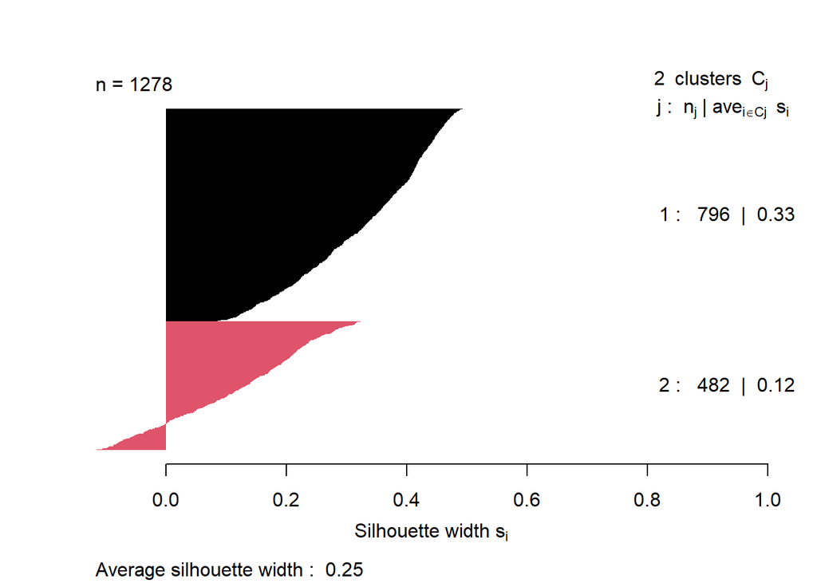

```r
d <- dist(X, method="euclidean")
sil = silhouette(groups, d)
plot(sil, col=1:2, main="", border=NA)
```

```r
summary(sil)
```

```
## Silhouette of 1278 units in 2 clusters from silhouette.default(x = groups, dist = d) :
##  Cluster sizes and average silhouette widths:
##       796       482
## 0.3291261 0.1173392
## Individual silhouette widths:
##    Min. 1st Qu.  Median    Mean 3rd Qu.    Max.
## -0.1171  0.1473  0.2547  0.2493  0.3798  0.4933
```

This metric can have different interpretations depending on the value obtained (check bibliography, Rosok Silhouette analysis): - Values close to 1 suggest that the observation is well matched to the assigned cluster - Values close to 0 suggest that the observation is borderline matched between two clusters - Values close to -1 suggest that the observations may be assigned to the wrong cluster

The values are 0.33 and 0.12 approx.. Hence, the observation is borderline matched between two clusters which corresponds to our results

4. Profiles

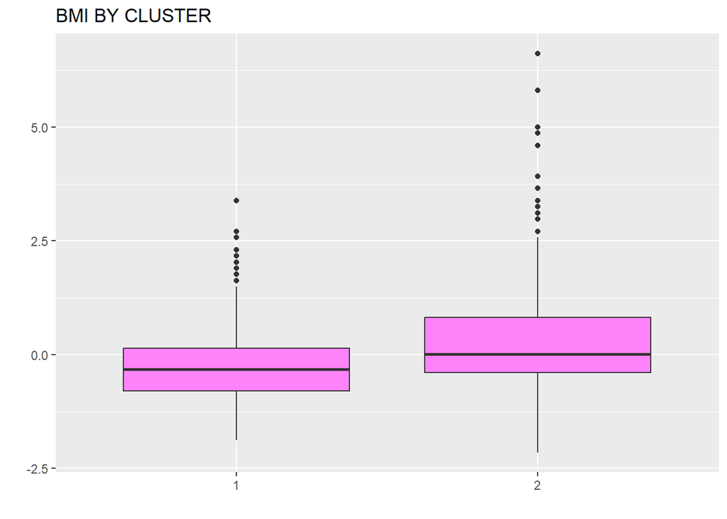

```r
as.data.frame(X) %>% mutate(cluster=factor(groups), BMI=BMI) %>%
  ggplot(aes(x = cluster, y = BMI)) +
  geom_boxplot(fill="orchid1") +
  labs(title = "BMI BY CLUSTER", x = "", y = "", col = "")
```

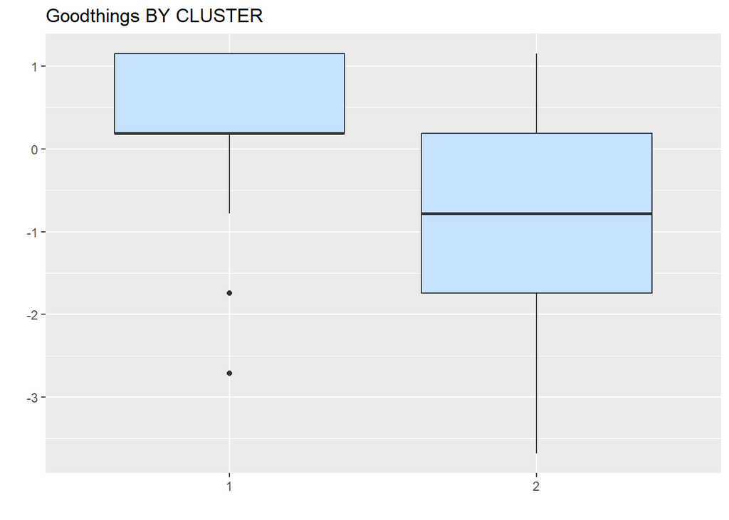

```r
as.data.frame(X) %>% mutate(cluster=factor(groups), Goodthings=Goodthings) %>%
  ggplot(aes(x = cluster, y =Goodthings)) +
  geom_boxplot(fill="slategray1") +
  labs(title = "Goodthings BY CLUSTER", x = "", y = "", col = "")
```

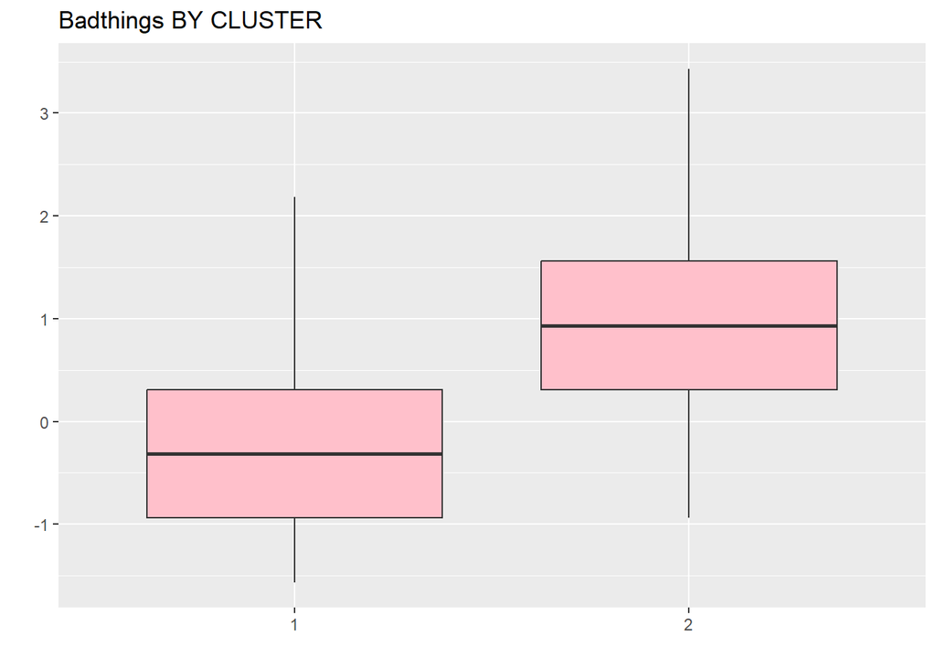

```r
as.data.frame(X) %>% mutate(cluster=factor(groups), Goodthings=Badthings) %>%
  ggplot(aes(x = cluster, y =Badthings)) +
  geom_boxplot(fill="pink") +
  labs(title = "Badthings BY CLUSTER", x = "", y = "", col = "")
```

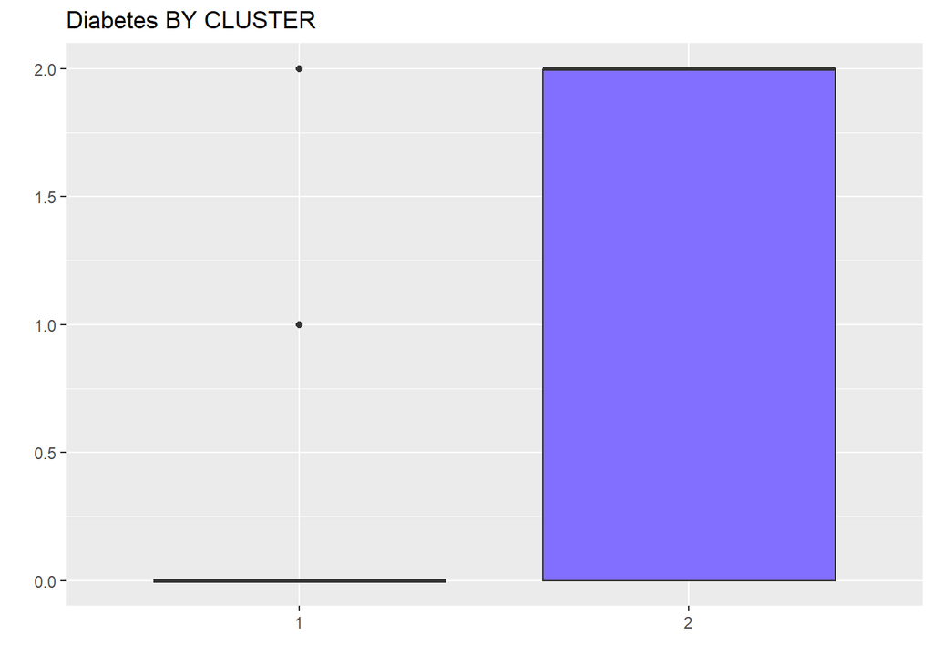

```r
as.data.frame(X) %>% mutate(cluster=factor(groups), Diabetes_012=data$Diabetes_012) %>%
  ggplot(aes(x = cluster, y =Diabetes_012)) +
  geom_boxplot(fill="#836FFF") +
  labs(title = "Diabetes BY CLUSTER", x = "", y = "", col = "")
```

We remark clusters differ depending on the variable. Higher values of Good Things and not having diabetes are in the same cluster, 1, whereas higher values of bad things, higher bmi and diabetes is in cluster 2. To see this in a clearer way we are going to make a clusplot.

5. Clusplot

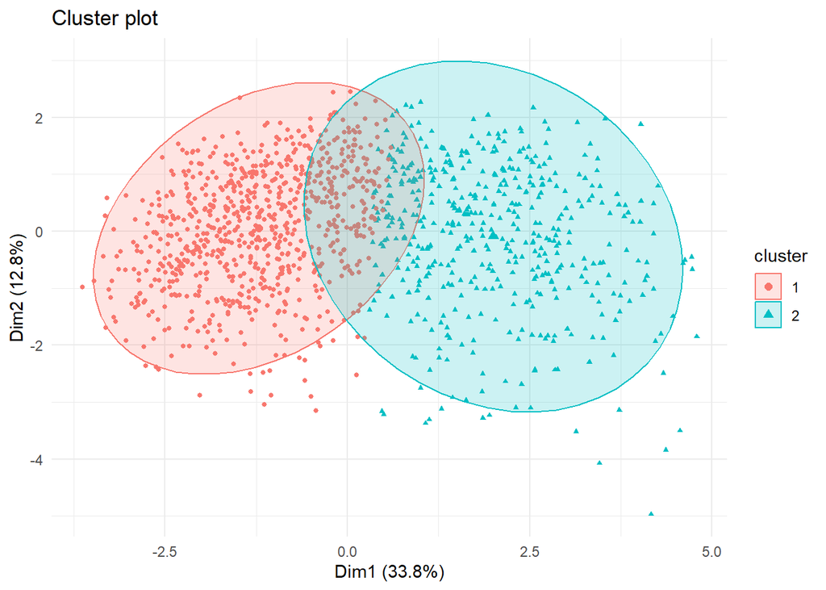

```r
fviz_cluster(fit, data = X,geom = c("point"), ellipse.type = 'norm', pointsize=1)+theme_minimal()
```

We can see cluster 1 has those variables considered more “healthy” (physical activity, veggies, lower bmi, no diabetes…). And the contrary happens for the other cluster which answers to our intial question.

## V) Bibliography

‘Factor Analysis | SPSS Annotated Output’. https://stats.oarc.ucla.edu/spss/output/factor-analysis/ (accessed Oct. 31, 2022).

J. Rodin, ‘Cultural and Psychosocial Determinants of Weight Concerns’, Ann. Intern. Med., vol. 119, no. 7_Part_2, pp. 643–645, Oct. 1993, doi: 10.7326/0003-4819-119-7_Part_2-199310011-00003.

J. Rosok, ‘Silhouette analysis | R’. https://campus.datacamp.com/courses/cluster-analysis-in-r/k-means-clustering?ex=9 (accessed Nov. 02, 2022).

M. Usman, S. Ahmed, J. Ferzund, A. Mehmood, and A. Rehman, ‘Using PCA and Factor Analysis for Dimensionality Reduction of Bio-informatics Data’, Int. J. Adv. Comput. Sci. Appl., vol. 8, no. 5, 2017, doi: 10.14569/IJACSA.2017.080551.

K. J. Preacher and R. C. MacCallum, ‘Repairing Tom Swift’s Electric Factor Analysis Machine’, Underst. Stat., vol. 2, no. 1, pp. 13–43, Feb. 2003, doi: 10.1207/S15328031US0201_02.